# Sparse Image Inpainting

# Sparse Image Inpainting

## Run this tour

Run the cells in order with a Python 3 kernel. The first cell locates the companion data and toolbox and installs missing dependencies when needed. All worked examples include their implementation directly in this notebook. Random seeds make comparisons reproducible; you can change them to explore other samples.

```python
# Locate the companion toolbox locally, or fetch it for a standalone/Colab copy.
from pathlib import Path
import importlib.util
import os
import subprocess
import sys

working = Path.cwd()
candidates = [working, working / "python", working.parent / "python"]
python_dir = next((p for p in candidates if (p / "nt_toolbox").is_dir()), None)
if python_dir is None:
    checkout = working / "numerical-tours-support"
    if not checkout.exists():
        subprocess.run(
            [
                "git",
                "clone",
                "--depth",
                "1",
                "--branch",
                "master",
                "https://github.com/gpeyre/numerical-tours.git",
                str(checkout),
            ],
            check=True,
        )
    python_dir = checkout / "python"
os.chdir(python_dir)
if str(python_dir) not in sys.path:
    sys.path.insert(0, str(python_dir))
requirements = python_dir / "requirements.txt"
if any(
    importlib.util.find_spec(name) is None
    for name in [
        "numpy",
        "scipy",
        "matplotlib",
        "skimage",
        "sklearn",
        "pywt",
        "ipywidgets",
        "cvxpy",
        "skfmm",
        "autograd",
        "progressbar",
        "celer",
    ]
):
    subprocess.run(
        [sys.executable, "-m", "pip", "install", "-r", str(requirements)], check=True
    )

import numpy as np
import matplotlib.pyplot as plt

np.random.seed(0)
plt.rcParams.update(
    {
        "figure.figsize": (8, 4),
        "figure.dpi": 100,
        "axes.spines.top": False,
        "axes.spines.right": False,
        "font.size": 11,
        "image.cmap": "gray",
    }
)
%matplotlib inline
```

$\newcommand{\dotp}[2]{\langle #1, #2 \rangle}$ $\newcommand{\enscond}[2]{\lbrace #1, #2 \rbrace}$ $\newcommand{\pd}[2]{ \frac{ \partial #1}{\partial #2} }$ $\newcommand{\umin}[1]{\underset{#1}{\min}\;}$ $\newcommand{\umax}[1]{\underset{#1}{\max}\;}$ $\newcommand{\uargmin}[1]{\underset{#1}{argmin}\;}$ $\newcommand{\norm}[1]{\|#1\|}$ $\newcommand{\abs}[1]{\left|#1\right|}$ $\newcommand{\choice}[1]{ \left\{ \begin{array}{l} #1 \end{array} \right. }$ $\newcommand{\pa}[1]{\left(#1\right)}$ $\newcommand{\diag}[1]{{diag}\left( #1 \right)}$ $\newcommand{\qandq}{\quad\text{and}\quad}$ $\newcommand{\qwhereq}{\quad\text{where}\quad}$ $\newcommand{\qifq}{ \quad \text{if} \quad }$ $\newcommand{\qarrq}{ \quad \Longrightarrow \quad }$ $\newcommand{\ZZ}{\mathbb{Z}}$ $\newcommand{\CC}{\mathbb{C}}$ $\newcommand{\RR}{\mathbb{R}}$ $\newcommand{\EE}{\mathbb{E}}$ $\newcommand{\Zz}{\mathcal{Z}}$ $\newcommand{\Ww}{\mathcal{W}}$ $\newcommand{\Vv}{\mathcal{V}}$ $\newcommand{\Nn}{\mathcal{N}}$ $\newcommand{\NN}{\mathcal{N}}$ $\newcommand{\Hh}{\mathcal{H}}$ $\newcommand{\Bb}{\mathcal{B}}$ $\newcommand{\Ee}{\mathcal{E}}$ $\newcommand{\Cc}{\mathcal{C}}$ $\newcommand{\Gg}{\mathcal{G}}$ $\newcommand{\Ss}{\mathcal{S}}$ $\newcommand{\Pp}{\mathcal{P}}$ $\newcommand{\Ff}{\mathcal{F}}$ $\newcommand{\Xx}{\mathcal{X}}$ $\newcommand{\Mm}{\mathcal{M}}$ $\newcommand{\Ii}{\mathcal{I}}$ $\newcommand{\Dd}{\mathcal{D}}$ $\newcommand{\Ll}{\mathcal{L}}$ $\newcommand{\Tt}{\mathcal{T}}$ $\newcommand{\si}{\sigma}$ $\newcommand{\al}{\alpha}$ $\newcommand{\la}{\lambda}$ $\newcommand{\ga}{\gamma}$ $\newcommand{\Ga}{\Gamma}$ $\newcommand{\La}{\Lambda}$ $\newcommand{\Si}{\Sigma}$ $\newcommand{\be}{\beta}$ $\newcommand{\de}{\delta}$ $\newcommand{\De}{\Delta}$ $\newcommand{\phi}{\varphi}$ $\newcommand{\th}{\theta}$ $\newcommand{\om}{\omega}$ $\newcommand{\Om}{\Omega}$

This numerical tour explores the use of sparse energies to regularize the image inpaiting problem.

```python
import numpy as np
import scipy as scp
import pylab as pyl
import matplotlib.pyplot as plt

from nt_toolbox.general import clamp, np, plt, pylab, rescale
from nt_toolbox.signal import imageplot, load_image, np, plt, pylab, snr

import warnings

%matplotlib inline
```

Here we consider inpainting of damaged observation without noise.

## Sparse Regularization

This tour consider measurements $y=\Phi f_0 + w$ where $\Phi$ is a masking operator and $w$ is an additive noise.

This tour is focused on using sparsity to recover an image from the measurements $y$. It considers a synthesis-based regularization, that compute a sparse set of coefficients $ (a_m^{\star})_m $ in a frame $\Psi = (\psi_m)_m$ that solves $$a^{\star} \in \text{argmin}_a \: \frac{1}{2}\|y-\Phi \Psi a\|^2 + \lambda J(a)$$

where $\lambda$ should be adapted to the noise level $\|w\|$. Since in this tour we consider damaged observation without noise, i.e. $w=0$, we use either a very small value of $\lambda$, or we decay its value through the iterations of the recovery process.

Here we use the notation $$\Psi a = \sum_m a_m \psi_m$$ to indicate the reconstruction operator, and $J(a)$ is the $\ell^1$ sparsity prior $$J(a)=\sum_m \|a_m\|.$$

## Missing Pixels and Inpainting

Inpainting corresponds to filling holes in images. This corresponds to a linear ill posed inverse problem.

You might want to do first the numerical tour *Variational image inpaiting* that use Sobolev and TV priors to performs the inpainting.

First we load the image to be inpainted.

```python
n = 128
f0 = load_image("nt_toolbox/data/lena.bmp")
f0 = rescale(f0[256 - n // 2 : 256 + n // 2, 256 - n // 2 : 256 + n // 2])
```

Display it.

[figure not shown]

```python
plt.figure(figsize=(6, 6))
imageplot(f0, "Image f_0")
```

Amount of removed pixels.

```python
rho = 0.7
```

Then we construct a mask $\Omega$ made of random pixel locations.

```python
from numpy import random

Omega = np.zeros([n, n])
sel = random.permutation(n**2)
np.ravel(Omega)[sel[np.arange(int(rho * n**2))]] = 1
```

The damaging operator put to zeros the pixel locations $x$ for which $\Omega(x)=1$

```python
Phi = lambda f, Omega: f * (1 - Omega)
```

The damaged observations reads $y = \Phi f_0$.

```python
y = Phi(f0, Omega)
```

Display the observations.

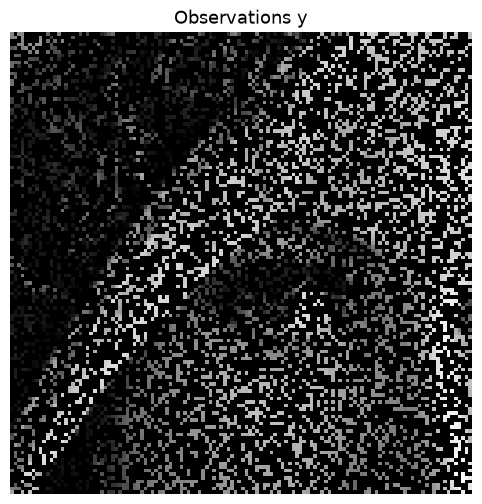

```python
plt.figure(figsize=(6, 6))
imageplot(y, "Observations y")
```

## Soft Thresholding in a Basis

The soft thresholding operator is at the heart of $\ell^1$ minimization schemes. It can be applied to coefficients $a$, or to an image $f$ in an ortho-basis.

The soft thresholding is a 1-D functional that shrinks the value of coefficients. $$ s_T(u)=\max(0,1-T/|u|)u $$

Define a shortcut for this soft thresholding 1-D functional.

```python
SoftThresh = lambda x, T: (
    x
    * np.maximum(
        1 - T / np.maximum(abs(x), 1e-10 * np.ones(np.shape(x))), np.zeros(np.shape(x))
    )
)
```

Display a curve of the 1D soft thresholding.

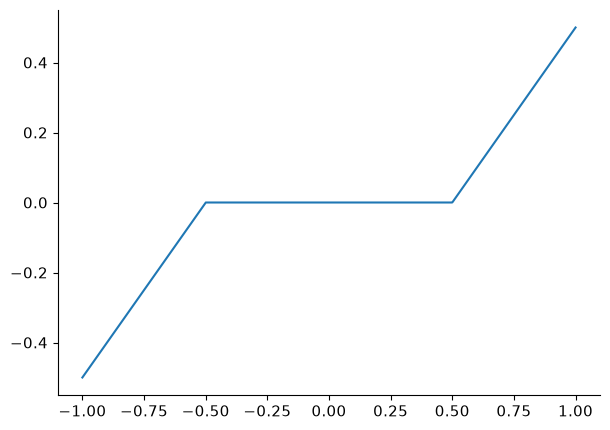

```python
x = np.linspace(-1, 1, 1000)

plt.figure(figsize=(7, 5))
plt.plot(x, SoftThresh(x, 0.5))
plt.show()
```

Note that the function SoftThresh can also be applied to vector which defines an operator on coefficients: $$ S_T(a) = ( s_T(a_m) )_m. $$

In the next section, we use an orthogonal wavelet basis $\Psi$.

We set the parameters of the wavelet transform.

```python
Jmax = np.log2(n) - 1
Jmin = Jmax - 3
```

Shortcut for $\Psi$ and $\Psi^*$ in the orthogonal case.

```python
from nt_toolbox.perform_wavelet_transf import np, perform_wavelet_transf

Psi = lambda a: perform_wavelet_transf(a, Jmin, -1, ti=0)
PsiS = lambda f: perform_wavelet_transf(f, Jmin, +1, ti=0)
```

The soft thresholding opterator in the basis $\Psi$ is defined as $$S_T^\Psi(f) = \sum_m s_T( \langle f,\psi_m \rangle ) \psi_m $$

It thus corresponds to applying the transform $\Psi^*$, thresholding the coefficients using $S_T$ and then undoing the transform using $\Psi$. $$ S_T^\Psi(f) = \Psi \circ S_T \circ \Psi^*$$

```python
SoftThreshPsi = lambda f, T: Psi(SoftThresh(PsiS(f), T))
```

This soft thresholding corresponds to a denoising operator.

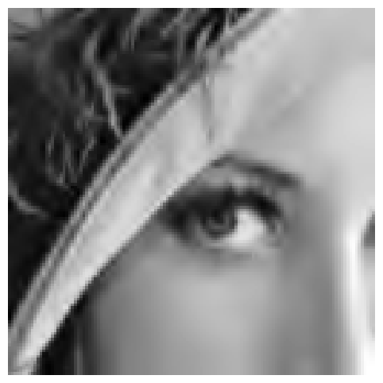

```python
plt.figure(figsize=(6, 6))
imageplot(clamp(SoftThreshPsi(f0, 0.1)))
```

## Inpainting using Orthogonal Wavelet Sparsity

If $\Psi$ is an orthogonal basis, a change of variable shows that the synthesis prior is also an analysis prior, that reads $$f^{\star} \in \text{argmin}_f \: E(f) = \frac{1}{2}\|y-\Phi f\|^2 + \lambda \sum_m \|\langle f,\psi_m \rangle\|. $$

To solve this non-smooth optimization problem, one can use forward-backward splitting, also known as iterative soft thresholding.

It computes a series of images $f^{(\ell)}$ defined as $$ f^{(\ell+1)} = S_{\tau\lambda}^{\Psi}( f^{(\ell)} - \tau \Phi^{*} (\Phi f^{(\ell)} - y) ) $$

Set up the value of the threshold.

```python
lambd = 0.03
```

In our setting, we have $ \Phi^* = \Phi $ which is an operator of norm 1.

For $f^{(\ell)}$ to converge to a solution of the problem, the gradient step size should be chosen as $$\tau < \frac{2}{\|\Phi^* \Phi\|} = 2$$

In the following we use: $$\tau = 1$$

Since we use $ \tau=1 $ and $ \Phi = \Phi^* = \text{diag}(1-\Omega) $, the gradient descent step is a projection on the inpainting constraint $$ C = \{ f \backslash \forall \Omega(x)=0, f(x)=y(x) \} $$ One thus has $$ f - \tau \Phi^{*} (\Phi f - y) = \text{Proj}_C(f) $$

For the sake of simplicity, we define a shortcut for this projection operator.

```python
ProjC = lambda f, Omega: Omega * f + (1 - Omega) * y
```

Each iteration of the forward-backward (iterative thresholding) algorithm thus reads: $$ f^{(\ell+1)} = S_{\lambda}^\Psi( \text{Proj}_C(f^{(\ell)}) ). $$

Initialize the iterations.

```python
fSpars = y
```

First step: gradient descent.

```python
fSpars = ProjC(fSpars, Omega)
```

Second step: denoise the solution by thresholding.

```python
fSpars = SoftThreshPsi(fSpars, lambd)
```

**Worked example 1**

Perform the iterative soft thresholding. Monitor the decay of the energy $E$ you are minimizing.

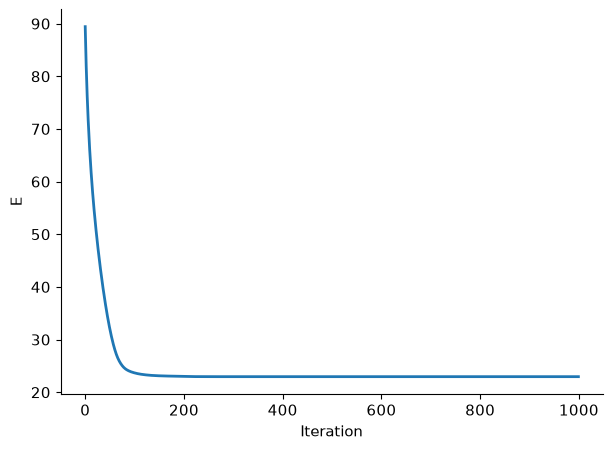

```python
from numpy import linalg

fSpars = y
energy = []
niter = 1000
for i in range(niter):
    fSpars = SoftThreshPsi(ProjC(fSpars, Omega), lambd)
    # record the energy
    fW = PsiS(fSpars)
    energy = energy + [
        1 / 2 * linalg.norm(y - Phi(fSpars, Omega), "fro") ** 2
        + lambd * np.sum(abs(fW))
    ]

plt.figure(figsize=(7, 5))
plt.plot(energy, linewidth=2)
plt.xlabel("Iteration")
plt.ylabel("E")
plt.show()
```

Display the result.

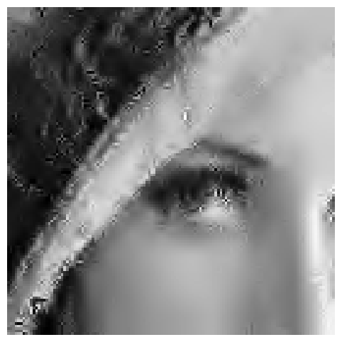

```python
plt.figure(figsize=(6, 6))
imageplot(clamp(fSpars))
```

**Worked example 2**

Since there is no noise, one should in theory take $\lambda \rightarrow 0$. To do this, decay the value of $\lambda$ through the iterations.

[figure not shown]

```python
niter = 1000
lambda_list = np.linspace(0.03, 0, niter)
err = []

for i in range(niter):
    fSpars = SoftThreshPsi(ProjC(fSpars, Omega), lambda_list[i])

plt.figure(figsize=(6, 6))
imageplot(clamp(fSpars), "Sparsity inpainting, SNR = %.1f dB" % snr(f0, fSpars))
```

## Inpainting using Translation Invariant Wavelet Sparsity

Orthogonal sparsity performs a poor regularization because of the lack of translation invariance. This regularization is enhanced by considering $\Psi$ as a redundant tight frame of translation invariant wavelets.

One thus looks for optimal coefficients $a^\star$ that solves $$a^{\star} \in \text{argmin}_a \: E(a) = \frac{1}{2}\|y-\Phi \Psi a\|^2 + \lambda J(a)$$

*Important*: The operator $\Psi^*$ is the forward translation invariant wavelet transform. It computes the inner product with the unit norm wavelet atoms: $$ (\Psi^* f)_m = \langle f,\psi_m \rangle \quad \text{with} \quad \|\psi_m\|=1. $$

The reconstruction operator $\Xi$ satisfies $ \Xi \Psi^* f = f $, and is the pseudo inverse of the analysis operator $ \Xi = (\Psi^*)^+ $.

For our algorithm, we will need to use $\Psi$ and not $\Xi$. Lukily, for the wavelet transform, one has $$ \Xi = \Psi \text{diag(U)} f $$ where $U_m$ account for the redundancy of the scale of the atom $\psi_m$.

Compute the scaling factor (inverse of the redundancy).

```python
J = Jmax - Jmin + 1
u = np.hstack(([4 ** (-J)], 4 ** (-np.floor(np.arange(J + 2.0 / 3, 1, -1.0 / 3)))))
U = np.transpose(np.tile(u, (n, n, 1)), (2, 0, 1))
```

Choose a value of the regularization parameter.

```python
lambd = 0.01
```

Shortcut for the wavelet transform and the reconstruction.

*Important:* Scilab users have to create files |Xi.m|, |PsiS.m| and |Psi.m| to implement this function.

```python
Xi = lambda a: perform_wavelet_transf(a, Jmin, -1, ti=1)
PsiS = lambda f: perform_wavelet_transf(f, Jmin, +1, ti=1)
Psi = lambda a: Xi(a / U)
```

The forward-backward algorithm now compute a series of wavelet coefficients $a^{(\ell)}$ computed as $$a^{(\ell+1)} = S_{\tau\lambda}( a^{(\ell)} + \Psi^*\Phi( y - \Phi\Psi a^{(\ell)} ) ). $$

The soft thresholding is defined as: $$\forall m, \quad S_T(a)_m = \max(0, 1-T/\|a_m\|)a_m. $$

The step size should satisfy: $$\tau < \frac{2}{\|\Psi\Phi \|} \leq 2 \min( u ). $$

```python
tau = 1.9 * np.min(u)
```

Initialize the wavelet coefficients with those of the previous reconstruction.

```python
a = U * PsiS(fSpars)
```

Gradient descent.

```python
fTI = Psi(a)
a = a + tau * PsiS(Phi(y - Phi(fTI, Omega), Omega))
```

Soft threshold.

```python
a = SoftThresh(a, lambd * tau)
```

**Worked example 3**

Perform the iterative soft thresholding. Monitor the decay of the energy $E$.

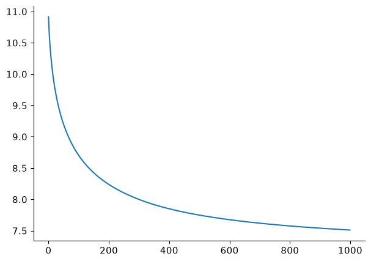

```python
niter = 1000
a = U * PsiS(fSpars)
E = []
for i in range(niter):
    fTI = Psi(a)
    d = y - Phi(fTI, Omega)
    E = E + [1 / 2 * linalg.norm(d, "fro") ** 2 + lambd * np.sum(abs(a))]
    # step
    a = SoftThresh(a + tau * PsiS(Phi(d, Omega)), lambd * tau)

plt.figure(figsize=(7, 5))
plt.plot(E)
plt.show()
```

Perform the reconstruction.

```python
fTI = Psi(a)
```

Display the result.

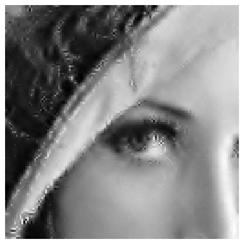

```python
plt.figure(figsize=(6, 6))
imageplot(clamp(fTI))
```

**Worked example 4**

Perform the iteration with a decaying value of $\lambda$

[figure not shown]

```python
niter = 3000
lambda_list = np.linspace(0.03, 0, niter)
err = []

for i in range(niter):
    fTI = Psi(a)
    d = y - Phi(fTI, Omega)
    # step
    a = SoftThresh(a + tau * PsiS(Phi(d, Omega)), lambda_list[i] * tau)

plt.figure(figsize=(6, 6))
imageplot(clamp(fSpars), "Sparsity inpainting TI, SNR = %.1f dB" % snr(f0, fTI))
```

## Inpainting using Iterative Hard Thresholding

To improve the sparsity of the solution, it is possible to replace the soft thresholding by a hard threshdoling. In this case, the resulting algorihtm does not perform anymore a variational minimization of an energy.

The hard thresholding is defined as $h_T(x)=0$ if $-T < x < T$ and $h_T(x)=x$ otherwise. It thus defines a thresholding operator of wavelet coefficients as $H_T(a)_m = h_T(a_m)$.

Define a shortcut for this vectorialized hard thresholding

*Important:* Scilab users have to create a file |HardThresh.m| to implement this function.

```python
HardThresh = lambda x, t: x * (abs(x) > t)
```

Display a curve of the 1-D Hard thresholding.

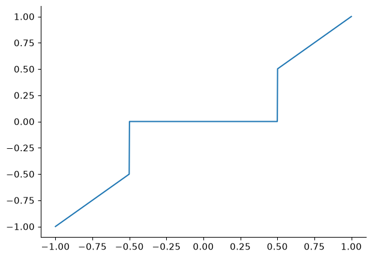

```python
x = np.linspace(-1, 1, 1000)

plt.figure(figsize=(7, 5))
plt.plot(x, HardThresh(x, 0.5))
plt.show()
```

The hard thresholding in the translation invariant wavelet basis $\Psi$ reads $$ H_T^\Psi(f) = \Xi \circ H_T \circ \Psi^* (f) $$ where $\Xi = (\Phi^*)^+$ is the reconstruction operator.

We follow the MCA paradigm of Jean-Luc Starck, that alternates between a gradient descent step and a hard thresholding denoising, using a decaying threshold. $$f^{(\ell+1)} = H_{\tau\lambda_\ell}^\Psi( f^{(\ell)} - \tau \Phi^*(\Phi f^{(\ell)} - y) ). $$

Number of iterations.

```python
niter = 500
```

List of thresholds. One must start by a large enough initial threshold.

```python
lambda_list = np.linspace(1, 0, niter)
```

Initialization.

```python
fHard = y
```

Gradient descent.

```python
fHard = ProjC(fHard, Omega)
```

Hard threshold (here $\lambda=\lambda_0$) is used).

```python
fHard = Xi(HardThresh(PsiS(fHard), tau * lambda_list[1]))
```

**Worked example 5**

Perform the iteration with a decaying value of $\lambda$

[figure not shown]

```python
lambda_list = np.linspace(1, 0, niter)
fHard = y

for i in range(niter):
    fHard = Xi(HardThresh(PsiS(ProjC(fHard, Omega)), lambda_list[i]))


plt.figure(figsize=(6, 6))
imageplot(clamp(fSpars), "Inpainting hard thresh., SNR = %.1f dB" % snr(f0, fHard))
```

## References and further reading

- Leonid Rudin, Stanley Osher, and Emad Fatemi. Nonlinear Total Variation Based Noise Removal Algorithms. 1992, Physica D 60, 259–268. The foundational total-variation image restoration model.
- Neal Parikh and Stephen Boyd. [Proximal Algorithms](https://web.stanford.edu/~boyd/papers/prox_algs.html). 2014, Foundations and Trends in Optimization 1(3), 127–239. Proximity operators and splitting methods for nonsmooth objectives.
- Amir Beck and Marc Teboulle. [A Fast Iterative Shrinkage-Thresholding Algorithm for Linear Inverse Problems](https://doi.org/10.1137/080716542). 2009, SIAM Journal on Imaging Sciences 2(1), 183–202. Accelerated proximal gradient descent and its convergence rate.
- Antonin Chambolle and Thomas Pock. [A First-Order Primal-Dual Algorithm for Convex Problems with Applications to Imaging](https://doi.org/10.1007/s10851-010-0251-1). 2011, Journal of Mathematical Imaging and Vision 40, 120–145. Primal–dual splitting for total variation and other composite penalties.
- Stéphane Mallat. [A Wavelet Tour of Signal Processing: The Sparse Way](https://www.di.ens.fr/~mallat/biblio.html). 2009, 3rd ed., Academic Press. Multiresolution analysis, sparse approximation, and wavelet algorithms.
- Stephen Boyd and Lieven Vandenberghe. [Convex Optimization](https://web.stanford.edu/~boyd/cvxbook/). 2004, Cambridge University Press. Convexity, duality, optimality conditions, and interior-point methods.